# Project: Communicate Data Findings (Dataset: Loan Data from prosper)

## Preliminary Wrangling

```python
# import all packages and set plots to be embedded inline
import numpy as np
import pandas as pd
import matplotlib.pyplot as plt
import seaborn as sb


%matplotlib inline
```

> Load in your dataset and describe its properties through the questions below. Try and motivate your exploration goals through this section.

```python
df = pd.read_csv('prosperLoanData.csv')
```

```python
df.head()
```

|  | ListingKey | ListingNumber | ListingCreationDate | CreditGrade | Term | LoanStatus | ClosedDate | BorrowerAPR | BorrowerRate | LenderYield | ... | LP_ServiceFees | LP_CollectionFees | LP_GrossPrincipalLoss | LP_NetPrincipalLoss | LP_NonPrincipalRecoverypayments | PercentFunded | Recommendations | InvestmentFromFriendsCount | InvestmentFromFriendsAmount | Investors |
| --- | --- | --- | --- | --- | --- | --- | --- | --- | --- | --- | --- | --- | --- | --- | --- | --- | --- | --- | --- | --- | --- |
| 0 | 1021339766868145413AB3B | 193129 | 2007-08-26 19:09:29.263000000 | C | 36 | Completed | 2009-08-14 00:00:00 | 0.16516 | 0.1580 | 0.1380 | ... | -133.18 | 0.0 | 0.0 | 0.0 | 0.0 | 1.0 | 0 | 0 | 0.0 | 258 |
| 1 | 10273602499503308B223C1 | 1209647 | 2014-02-27 08:28:07.900000000 | NaN | 36 | Current | NaN | 0.12016 | 0.0920 | 0.0820 | ... | 0.00 | 0.0 | 0.0 | 0.0 | 0.0 | 1.0 | 0 | 0 | 0.0 | 1 |
| 2 | 0EE9337825851032864889A | 81716 | 2007-01-05 15:00:47.090000000 | HR | 36 | Completed | 2009-12-17 00:00:00 | 0.28269 | 0.2750 | 0.2400 | ... | -24.20 | 0.0 | 0.0 | 0.0 | 0.0 | 1.0 | 0 | 0 | 0.0 | 41 |
| 3 | 0EF5356002482715299901A | 658116 | 2012-10-22 11:02:35.010000000 | NaN | 36 | Current | NaN | 0.12528 | 0.0974 | 0.0874 | ... | -108.01 | 0.0 | 0.0 | 0.0 | 0.0 | 1.0 | 0 | 0 | 0.0 | 158 |
| 4 | 0F023589499656230C5E3E2 | 909464 | 2013-09-14 18:38:39.097000000 | NaN | 36 | Current | NaN | 0.24614 | 0.2085 | 0.1985 | ... | -60.27 | 0.0 | 0.0 | 0.0 | 0.0 | 1.0 | 0 | 0 | 0.0 | 20 |

5 rows × 81 columns

```python
df.info()
```

```
<class 'pandas.core.frame.DataFrame'>
RangeIndex: 113937 entries, 0 to 113936
Data columns (total 81 columns):
 #   Column                               Non-Null Count   Dtype
---  ------                               --------------   -----
 0   ListingKey                           113937 non-null  object
 1   ListingNumber                        113937 non-null  int64
 2   ListingCreationDate                  113937 non-null  object
 3   CreditGrade                          28953 non-null   object
 4   Term                                 113937 non-null  int64
 5   LoanStatus                           113937 non-null  object
 6   ClosedDate                           55089 non-null   object
 7   BorrowerAPR                          113912 non-null  float64
 8   BorrowerRate                         113937 non-null  float64
 9   LenderYield                          113937 non-null  float64
```

[output cut: 73 more lines]

```python
df.shape
```

```
(113937, 81)
```

```python
df.describe()
```

|  | ListingNumber | Term | BorrowerAPR | BorrowerRate | LenderYield | EstimatedEffectiveYield | EstimatedLoss | EstimatedReturn | ProsperRating (numeric) | ProsperScore | ... | LP_ServiceFees | LP_CollectionFees | LP_GrossPrincipalLoss | LP_NetPrincipalLoss | LP_NonPrincipalRecoverypayments | PercentFunded | Recommendations | InvestmentFromFriendsCount | InvestmentFromFriendsAmount | Investors |
| --- | --- | --- | --- | --- | --- | --- | --- | --- | --- | --- | --- | --- | --- | --- | --- | --- | --- | --- | --- | --- | --- |
| count | 1.139370e+05 | 113937.000000 | 113912.000000 | 113937.000000 | 113937.000000 | 84853.000000 | 84853.000000 | 84853.000000 | 84853.000000 | 84853.000000 | ... | 113937.000000 | 113937.000000 | 113937.000000 | 113937.000000 | 113937.000000 | 113937.000000 | 113937.000000 | 113937.000000 | 113937.000000 | 113937.000000 |
| mean | 6.278857e+05 | 40.830248 | 0.218828 | 0.192764 | 0.182701 | 0.168661 | 0.080306 | 0.096068 | 4.072243 | 5.950067 | ... | -54.725641 | -14.242698 | 700.446342 | 681.420499 | 25.142686 | 0.998584 | 0.048027 | 0.023460 | 16.550751 | 80.475228 |
| std | 3.280762e+05 | 10.436212 | 0.080364 | 0.074818 | 0.074516 | 0.068467 | 0.046764 | 0.030403 | 1.673227 | 2.376501 | ... | 60.675425 | 109.232758 | 2388.513831 | 2357.167068 | 275.657937 | 0.017919 | 0.332353 | 0.232412 | 294.545422 | 103.239020 |
| min | 4.000000e+00 | 12.000000 | 0.006530 | 0.000000 | -0.010000 | -0.182700 | 0.004900 | -0.182700 | 1.000000 | 1.000000 | ... | -664.870000 | -9274.750000 | -94.200000 | -954.550000 | 0.000000 | 0.700000 | 0.000000 | 0.000000 | 0.000000 | 1.000000 |
| 25% | 4.009190e+05 | 36.000000 | 0.156290 | 0.134000 | 0.124200 | 0.115670 | 0.042400 | 0.074080 | 3.000000 | 4.000000 | ... | -73.180000 | 0.000000 | 0.000000 | 0.000000 | 0.000000 | 1.000000 | 0.000000 | 0.000000 | 0.000000 | 2.000000 |
| 50% | 6.005540e+05 | 36.000000 | 0.209760 | 0.184000 | 0.173000 | 0.161500 | 0.072400 | 0.091700 | 4.000000 | 6.000000 | ... | -34.440000 | 0.000000 | 0.000000 | 0.000000 | 0.000000 | 1.000000 | 0.000000 | 0.000000 | 0.000000 | 44.000000 |
| 75% | 8.926340e+05 | 36.000000 | 0.283810 | 0.250000 | 0.240000 | 0.224300 | 0.112000 | 0.116600 | 5.000000 | 8.000000 | ... | -13.920000 | 0.000000 | 0.000000 | 0.000000 | 0.000000 | 1.000000 | 0.000000 | 0.000000 | 0.000000 | 115.000000 |
| max | 1.255725e+06 | 60.000000 | 0.512290 | 0.497500 | 0.492500 | 0.319900 | 0.366000 | 0.283700 | 7.000000 | 11.000000 | ... | 32.060000 | 0.000000 | 25000.000000 | 25000.000000 | 21117.900000 | 1.012500 | 39.000000 | 33.000000 | 25000.000000 | 1189.000000 |

8 rows × 61 columns

```python
#finding null value
df.isnull().sum()
```

```
ListingKey                         0
ListingNumber                      0
ListingCreationDate                0
CreditGrade                    84984
Term                               0
                               ...
PercentFunded                      0
Recommendations                    0
InvestmentFromFriendsCount         0
InvestmentFromFriendsAmount        0
Investors                          0
Length: 81, dtype: int64
```

```python
#Let's find duplicate data set
df.duplicated().sum()
```

```
0
```

```python
#let's find NaN value
df.isna().sum()
```

```
ListingKey                         0
ListingNumber                      0
ListingCreationDate                0
CreditGrade                    84984
Term                               0
                               ...
PercentFunded                      0
Recommendations                    0
InvestmentFromFriendsCount         0
InvestmentFromFriendsAmount        0
Investors                          0
Length: 81, dtype: int64
```

```python
#checking duplicate data
df.duplicated().sum()
```

```
0
```

```python
df.info()
```

```
<class 'pandas.core.frame.DataFrame'>
RangeIndex: 113937 entries, 0 to 113936
Data columns (total 81 columns):
 #   Column                               Non-Null Count   Dtype
---  ------                               --------------   -----
 0   ListingKey                           113937 non-null  object
 1   ListingNumber                        113937 non-null  int64
 2   ListingCreationDate                  113937 non-null  object
 3   CreditGrade                          28953 non-null   object
 4   Term                                 113937 non-null  int64
 5   LoanStatus                           113937 non-null  object
 6   ClosedDate                           55089 non-null   object
 7   BorrowerAPR                          113912 non-null  float64
 8   BorrowerRate                         113937 non-null  float64
 9   LenderYield                          113937 non-null  float64
```

[output cut: 73 more lines]

### What is the structure of your dataset?

> This dataset contain 113,937 loans with 81 features.we can see more variable are in numeric form.Each loan contain information on the borrowered's background information and details regarding the loans.

### What is/are the main feature(s) of interest in your dataset?

> I'm looking forward for f the borrower's Annual Percentage Rate (APR) also I am more interested on finding the borrower's rating, score, occupation and income that could influence change in borrower's APR.

### What features in the dataset do you think will help support your investigation into your feature(s) of interest?

> I think loan amount will have impact on APR and also i am interested in borrower's monthly income. loan term, rating and job status, monthly payment. Let's find out if this will impact our data or not.I would like to look at following features:
1. ProsperScore
2. BorrowerRate
3. Loan status
4. Total Prosper Bill Payed
5. Income
6. Employment
7. Occupation

## Univariate Exploration

> In this section, investigate distributions of individual variables. If you see unusual points or outliers, take a deeper look to clean things up and prepare yourself to look at relationships between variables.

```python
col = ['ProsperScore', 'BorrowerAPR','BorrowerRate','Occupation', 'Term', 'IncomeRange', 'Term', 'EmploymentStatus',
        'LoanStatus','TotalProsperPaymentsBilled', 'LoanStatus']
df_sel = df[col]
```

```python
df_sel.head()
```

|  | ProsperScore | BorrowerAPR | BorrowerRate | Occupation | Term | IncomeRange | Term | EmploymentStatus | LoanStatus | TotalProsperPaymentsBilled | LoanStatus |
| --- | --- | --- | --- | --- | --- | --- | --- | --- | --- | --- | --- |
| 0 | NaN | 0.16516 | 0.1580 | Other | 36 | $25,000-49,999 | 36 | Self-employed | Completed | NaN | Completed |
| 1 | 7.0 | 0.12016 | 0.0920 | Professional | 36 | $50,000-74,999 | 36 | Employed | Current | NaN | Current |
| 2 | NaN | 0.28269 | 0.2750 | Other | 36 | Not displayed | 36 | Not available | Completed | NaN | Completed |
| 3 | 9.0 | 0.12528 | 0.0974 | Skilled Labor | 36 | $25,000-49,999 | 36 | Employed | Current | NaN | Current |
| 4 | 4.0 | 0.24614 | 0.2085 | Executive | 36 | $100,000+ | 36 | Employed | Current | 11.0 | Current |

```python
df_sel.info()
```

```
<class 'pandas.core.frame.DataFrame'>
RangeIndex: 113937 entries, 0 to 113936
Data columns (total 11 columns):
 #   Column                      Non-Null Count   Dtype
---  ------                      --------------   -----
 0   ProsperScore                84853 non-null   float64
 1   BorrowerAPR                 113912 non-null  float64
 2   BorrowerRate                113937 non-null  float64
 3   Occupation                  110349 non-null  object
 4   Term                        113937 non-null  int64
 5   IncomeRange                 113937 non-null  object
 6   Term                        113937 non-null  int64
 7   EmploymentStatus            111682 non-null  object
 8   LoanStatus                  113937 non-null  object
 9   TotalProsperPaymentsBilled  22085 non-null   float64
 10  LoanStatus                  113937 non-null  object
dtypes: float64(4), int64(2), object(5)
memory usage: 9.6+ MB
```

```python
#let's change data type to proper format
df_sel['Term'] = df_sel['Term'].astype('category')
df_sel['IncomeRange'] = df_sel['IncomeRange'].astype('category')
df_sel['EmploymentStatus'] = df['EmploymentStatus'].astype('category')
df_sel['LoanStatus'] = df_sel['LoanStatus'].astype('category')
df_sel.info()
```

```
<class 'pandas.core.frame.DataFrame'>
RangeIndex: 113937 entries, 0 to 113936
Data columns (total 11 columns):
 #   Column                      Non-Null Count   Dtype
---  ------                      --------------   -----
 0   ProsperScore                84853 non-null   float64
 1   BorrowerAPR                 113912 non-null  float64
 2   BorrowerRate                113937 non-null  float64
 3   Occupation                  110349 non-null  object
 4   Term                        113937 non-null  object
 5   IncomeRange                 113937 non-null  category
 6   Term                        113937 non-null  object
 7   EmploymentStatus            111682 non-null  category
 8   LoanStatus                  113937 non-null  object
 9   TotalProsperPaymentsBilled  22085 non-null   float64
 10  LoanStatus                  113937 non-null  object
dtypes: category(2), float64(4), object(5)
memory usage: 8.0+ MB
```

### 1. Prosper Score

```python
df['ProsperScore'].value_counts()
```

```
4.0     12595
6.0     12278
8.0     12053
7.0     10597
5.0      9813
3.0      7642
9.0      6911
2.0      5766
10.0     4750
11.0     1456
1.0       992
Name: ProsperScore, dtype: int64
```

```python
df['ProsperScore'].describe()
```

```
count    84853.000000
mean         5.950067
std          2.376501
min          1.000000
25%          4.000000
50%          6.000000
75%          8.000000
max         11.000000
Name: ProsperScore, dtype: float64
```

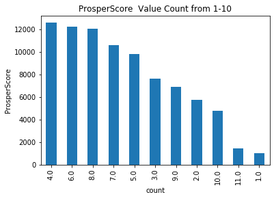

```python
#plotting prosperscore
df['ProsperScore'].value_counts().plot(kind='bar')
plt.title('ProsperScore  Value Count from 1-10')
plt.xlabel('count')
plt.ylabel('ProsperScore')
plt.fontsize = 12
plt.figsize=(12,12)
```

```python
#let's exclude proser score of 11
df_sel = df_sel[df_sel['ProsperScore'] != 11]
```

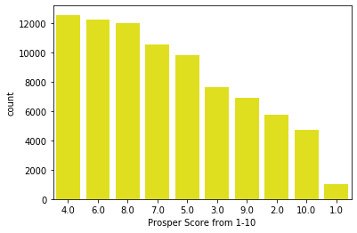

```python
# The score ranges from 1-10, removing prosper score of 11)
sb.countplot(data = df_sel, x = 'ProsperScore', color = 'yellow', order = df_sel['ProsperScore'].value_counts().index)
plt.xlabel('Prosper Score from 1-10');
```

> we can conclude that 4 is most common Prosper score while the majority of the customer have a score between 5-8.Furthermore, not many borrowers received the highest score of 10

### 2. Borrower APR

```python
# let;s find apr count
df.BorrowerAPR.value_counts().head()
```

```
0.35797    3672
0.35643    1644
0.37453    1260
0.30532     902
0.29510     747
Name: BorrowerAPR, dtype: int64
```

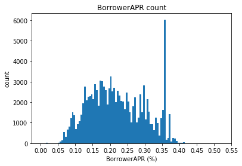

```python
# let's find counts for all BorrowerAPR values
bins = np.arange(0, df_sel['BorrowerAPR'].max(), 0.005)
plt.hist(data = df_sel, x = 'BorrowerAPR', bins = bins)
plt.title('BorrowerAPR count')
plt.xlabel('BorrowerAPR (%)')
plt.ylabel('count')
plt.xticks(np.arange(0, df_sel['BorrowerAPR'].max()+0.05, 0.05));
```

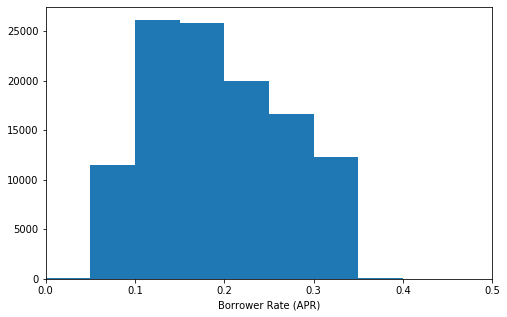

```python
binsize = 0.05
bins = np.arange(0, df_sel['BorrowerRate'].max()+binsize, binsize)
plt.figure(figsize=[8, 5])
plt.hist(data=df_sel,x="BorrowerRate", bins = bins)
plt.xlim([0,0.5])
plt.xlabel('Borrower Rate (APR)')
plt.show()
```

> One can see in the histogramm that most of the borrowers have an interest rate between of 0.1 and 0.25

### 3. Loan status

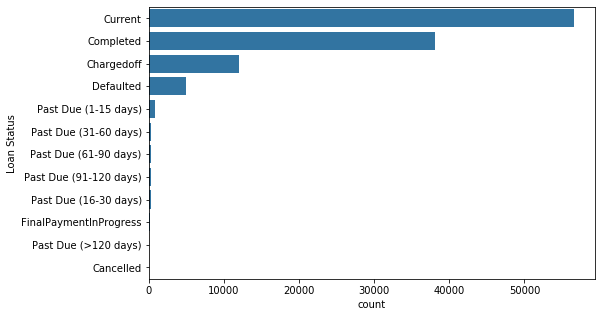

```python
#let's look at loan status

# start with a standard-scaled plot
plt.figure(figsize=[8, 5])
base_color=sb.color_palette()[0]
LoanStatus_order=df["LoanStatus"].value_counts().index
sb.countplot(data = df, y = 'LoanStatus',color=base_color,order=LoanStatus_order)
plt.ylabel('Loan Status')
plt.show()
```

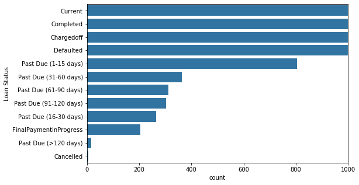

```python
#let's explore more
# Let's zome in and see what is going on there.
plt.figure(figsize=[8, 5])
base_color=sb.color_palette()[0]
LoanStatus_order=df["LoanStatus"].value_counts().index
sb.countplot(data = df, y = 'LoanStatus',color=base_color,order=LoanStatus_order)
plt.ylabel('Loan Status')
plt.xlim(0,1000)
plt.show()
```

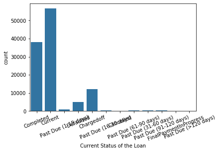

```python
base_color = sb.color_palette()[0]
sb.countplot(data = df, x = 'LoanStatus', color = base_color)
plt.xlabel('Current Status of the Loan')
plt.xticks(rotation = 22);
```

### .4 TotalProsperPaymentsBilled.

```python
df_sel.TotalProsperPaymentsBilled.describe()
```

```
count    21258.000000
mean        22.643381
std         18.936326
min          0.000000
25%          9.000000
50%         16.000000
75%         33.000000
max        141.000000
Name: TotalProsperPaymentsBilled, dtype: float64
```

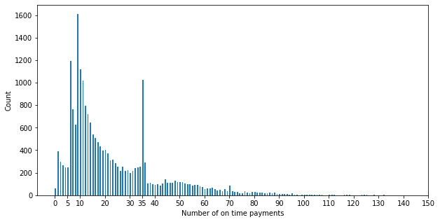

```python
binsize = 0.5
bins = np.arange(df_sel.TotalProsperPaymentsBilled.min(), df_sel.TotalProsperPaymentsBilled.max()+binsize, binsize)

plt.figure(figsize=[10, 5])
plt.hist(data = df_sel, x = 'TotalProsperPaymentsBilled', bins = bins)
plt.xlabel('Number of on time payments')
plt.ylabel('Count')
plt.xticks([0,5,10,20,30,35,40,50,60,70,80,90,100,110,120,130,140,150])
plt.show()
```

### 5. Income Range

```python
df_sel.IncomeRange.describe()
```

```
count             112481
unique                 8
top       $25,000-49,999
freq               32064
Name: IncomeRange, dtype: object
```

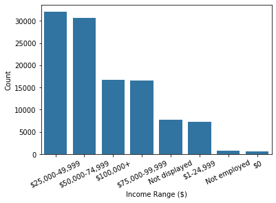

```python
#let's plot Income range
sb.countplot(data= df_sel, x= 'IncomeRange', color= base_color, order=df_sel['IncomeRange'].value_counts().index)
plt.xticks(rotation=25)
plt.xlabel('Income Range ($)')
plt.ylabel('Count');
```

> The income range of the borrowers shows that most of the loans where give to customers with a income between 25,000 and 74,999 which indicates that the borrowers are mostly middle-class

### 6 Employment Status

```python
df_sel.EmploymentStatus.describe()
```

```
count       110226
unique           8
top       Employed
freq         65957
Name: EmploymentStatus, dtype: object
```

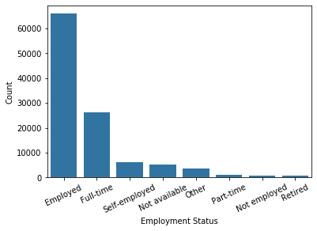

```python
# plotting EmploymentStatus
sb.countplot(data= df_sel, x= 'EmploymentStatus', color= base_color, order=df_sel['EmploymentStatus'].value_counts().index)
plt.xticks(rotation=25)
plt.xlabel('Employment Status')
plt.ylabel('Count');
```

> As expected are most of the borrowers employed of some kind (full-time, part-time, self-emplpoyed) but the data shows that even unemployed and retired persons could get a loan.

### 7 Occupation

```python
df_sel.Occupation.describe()
```

```
count     108913
unique        67
top        Other
freq       28331
Name: Occupation, dtype: object
```

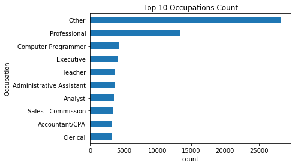

```python
# plotting Occupation
df_sel['Occupation'].value_counts()[9::-1].plot(kind='barh')
plt.title('Top 10 Occupations Count')
plt.xlabel('count')
plt.ylabel('Occupation')
plt.fontsize = 12
plt.figsize=(12,12)
```

> Let's plot the following as well:

*Recommendations*

*BorrowerAPR*

*OpenCreditLines*

*LoanOriginalAmount*

*MonthlyLoanPayment*

```python
df.Term.describe()
df.Term.value_counts()
```

```
36    87778
60    24545
12     1614
Name: Term, dtype: int64
```

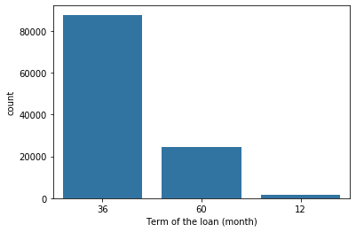

```python
#plotting Term

sb.countplot(data=df, x='Term', color=base_color, order = df['Term'].value_counts().index)
plt.xlabel('Term of the loan (month)');
```

```python
df.LoanOriginalAmount.mean()
```

```
8337.013849759078
```

> From this data we can say that most of the month is for 36 month adn Amount is 8337 USD.

```python
df.Recommendations.describe()
```

```
count    113937.000000
mean          0.048027
std           0.332353
min           0.000000
25%           0.000000
50%           0.000000
75%           0.000000
max          39.000000
Name: Recommendations, dtype: float64
```

```python
df.Recommendations.value_counts()
```

```
0     109678
1       3516
2        568
3        108
4         26
5         14
9          6
7          5
6          4
8          3
16         2
18         2
24         1
14         1
19         1
21         1
39         1
Name: Recommendations, dtype: int64
```

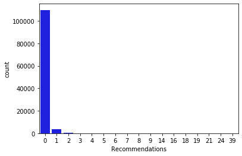

```python
# plotting Recommendations(Number of recommendations the borrower had at the time of the loan)
sb.countplot(data=df, x = 'Recommendations', color = 'blue');
```

> It seems we have an outlier also it seems from the data that we get that recommendation does not play vital factor for loan.

```python
df.OpenCreditLines.describe()
```

```
count    106333.000000
mean          9.260164
std           5.022644
min           0.000000
25%           6.000000
50%           9.000000
75%          12.000000
max          54.000000
Name: OpenCreditLines, dtype: float64
```

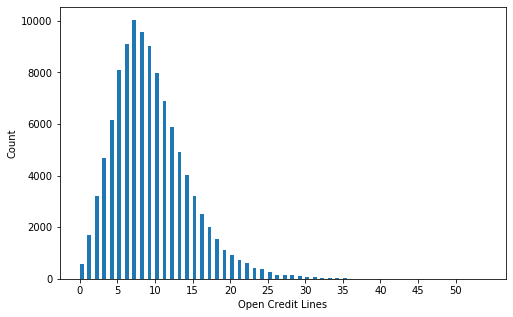

```python
binsize = 0.5
bins = np.arange(0, df.OpenCreditLines.max()+binsize, binsize)

plt.figure(figsize=[8, 5])
plt.hist(data = df, x = 'OpenCreditLines', bins = bins)
plt.xlabel('Open Credit Lines')
plt.ylabel('Count')
plt.xticks([0,5,10,15,20,25,30,35,40,45,50])
plt.show()
```

> We have right skewed with most borrowers having between 5 and 15 open credit lines.

```python
df.LoanOriginalAmount.describe()
```

```
count    113937.00000
mean       8337.01385
std        6245.80058
min        1000.00000
25%        4000.00000
50%        6500.00000
75%       12000.00000
max       35000.00000
Name: LoanOriginalAmount, dtype: float64
```

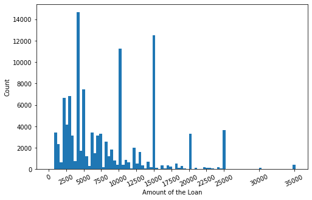

```python
binsize = 400
bins = np.arange(0, df.LoanOriginalAmount.max()+binsize, binsize)

plt.figure(figsize=[8, 5])
plt.hist(data = df, x = 'LoanOriginalAmount', bins = bins)
plt.xlabel('Amount of the Loan')
plt.ylabel('Count')
plt.xticks([0,2500,5000,7500,10000,12500,15000,17500,20000,22500,25000,30000,35000], rotation=25)
plt.show()
```

> The distribution has serval peaks at around 4,000, 10,000 and 15,000. But most of the values are in the lower end between 2500 and 10,000. The most loaned amounts are 4,000 and 15,000.

```python
df.MonthlyLoanPayment.describe()
```

```
count    113937.000000
mean        272.475783
std         192.697812
min           0.000000
25%         131.620000
50%         217.740000
75%         371.580000
max        2251.510000
Name: MonthlyLoanPayment, dtype: float64
```

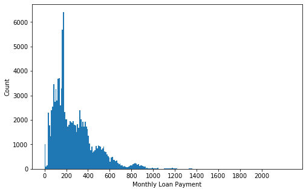

```python
binsize = 10
bins = np.arange(df.MonthlyLoanPayment.min(), df.MonthlyLoanPayment.max()+binsize, binsize)

plt.figure(figsize=[8, 5])
plt.hist(data = df, x = 'MonthlyLoanPayment', bins = bins)
plt.xlabel('Monthly Loan Payment')
plt.ylabel('Count')
plt.xticks([0,200,400,600,800,1000,1200,1400,1600,1800,2000])
plt.show()
```

> We have right skewed distribution with monthly payment .

### Of the features you investigated, were there any unusual distributions? Did you perform any operations on the data to tidy, adjust, or change the form of the data? If so, why did you do this?

> Listed as below:
- In Employment status that people that are not employed, not displayed their income or have an income of 0 received a loan from Prosper as well.
- Loan amounts has several peaks: the two most loaned amounts (the two highest peaks in the distribution, 4000 & 15000) have such a difference in terms of the loan amount.
- As expected are most of the borrowers employed of some kind (full-time, part-time, self-emplpoyed) but the data shows that even unemployed and retired persons could get a loan.

## Bivariate Exploration

> In this section, investigate relationships between pairs of variables in your data. Make sure the variables that you cover here have been introduced in some fashion in the previous section (univariate exploration).

> let's look at correlations present between features in the data.

```python
ordinal={"ProsperScore":[1,2,3,4,5,6,7,8,9,10,11,12,13]}
for var in ordinal:
    pd_ver=pd.__version__.split(".")
    if (int(pd_ver[0])>0) or (int(pd_ver[1])>=21): #v0.21 or later
        ordered_var=pd.api.types.CategoricalDtype(ordered=True,categories=ordinal[var])
        df[var]=df[var].astype("category")
    else: # pre_v0.21
        df[var]=df.astype("category", ordered=True,categories=ordinal_var[var])
```

```python
variable_num = ['BorrowerRate', 'CurrentCreditLines', 'TotalCreditLinespast7years',
                'OpenCreditLines', 'DebtToIncomeRatio',
                'Recommendations','LoanOriginalAmount','EmploymentStatusDuration']

#categoric_vars = ['LoanStatus', 'ProsperScore', 'EmploymentStatus','BorrowerState','Occupation', 'IncomeRange']
categoric_var = ['LoanStatus', 'ProsperScore', 'EmploymentStatus','IncomeRange']
```

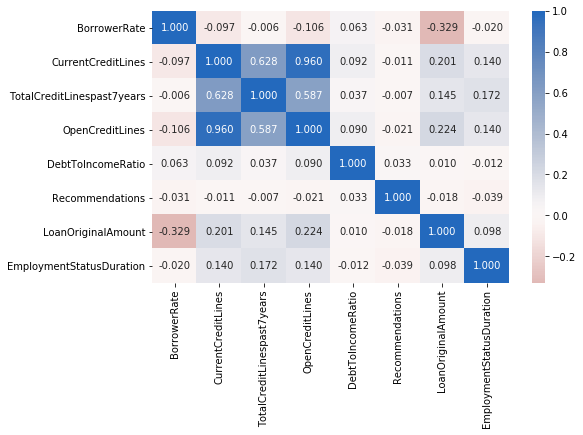

```python
#let's find co relation
plt.figure(figsize = [8, 5])
sb.heatmap(df[variable_num].corr(), annot = True, fmt = '.3f',
           cmap = 'vlag_r', center = 0)
plt.show()
```

> Isngiht
> - OpenCreditLines and CurrentCreditLines is 0.96
> - CurrentCreditLines and TotalCreditLinespast7years is 0.628
> - OpenCreditLines and TotalCreditLinespast7years is 0.587
> - Negaitve corelation between Loan Orginam amount and borrow amount

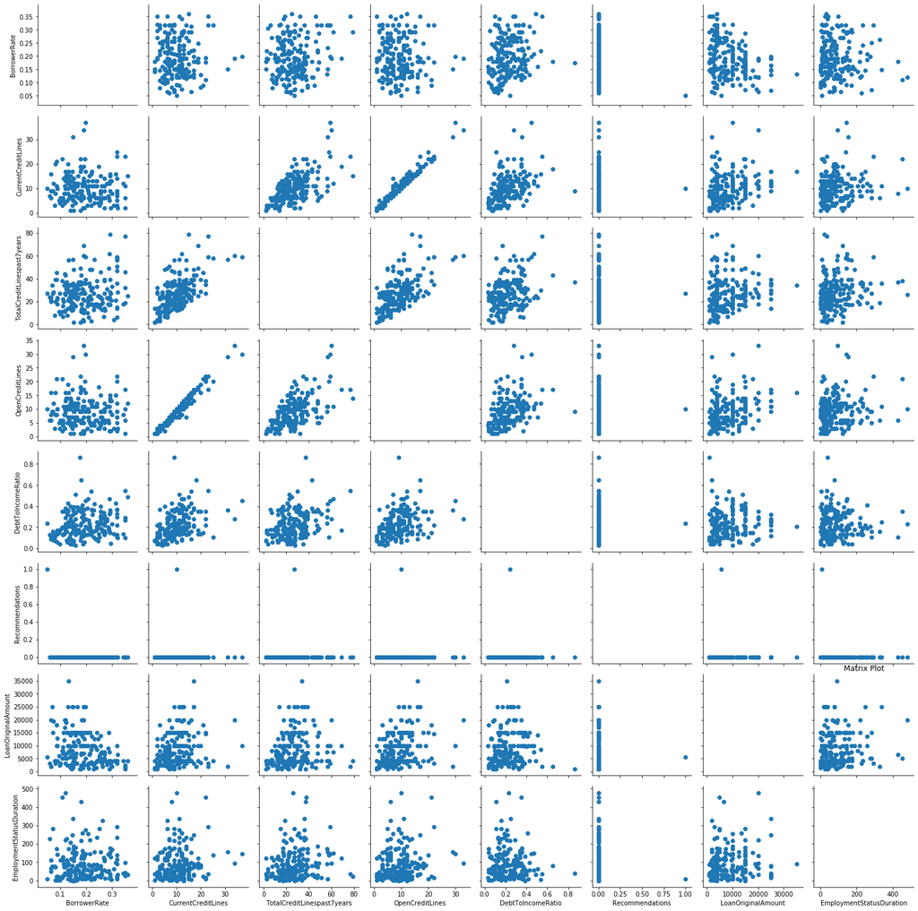

```python
#plotting the graph usng 200 ranodm value matrix plot

samples = np.random.choice(df.shape[0], 200, replace = False)
loan_samp = df.loc[samples,:]

g = sb.PairGrid(data = loan_samp, vars = variable_num )
g.map_offdiag(plt.scatter)
plt.title('Matrix Plot');
```

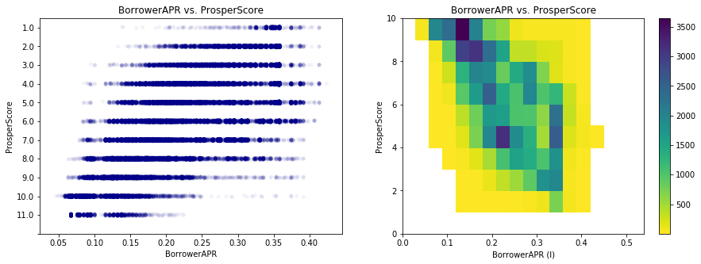

```python
#let's dig further  ProsperScore vs BorrowerAPR
plt.figure(figsize = [15, 5])
plt.subplot(1, 2, 1)
sb.stripplot(data = df, x = 'BorrowerAPR', y = 'ProsperScore', jitter = 0.05, alpha = 0.05, orient='h',color='darkblue')
plt.yticks(np.arange(0, 12, 1))
plt.title('BorrowerAPR vs. ProsperScore')
plt.xlabel('BorrowerAPR')
plt.ylabel('ProsperScore')


plt.subplot(1, 2, 2)
bins_x = np.arange(0, df_sel['BorrowerAPR'].max()+0.05, 0.03)
bins_y = np.arange(0, df_sel['ProsperScore'].max()+1, 1)
plt.hist2d(data = df_sel, x = 'BorrowerAPR', y = 'ProsperScore', bins = [bins_x, bins_y],
               cmap = 'viridis_r', cmin = 0.5)
plt.colorbar()
plt.title('BorrowerAPR vs. ProsperScore')
plt.xlabel('BorrowerAPR (l)')
plt.ylabel('ProsperScore');
```

> BorrowerAPR vs. ProsperScore: T people with higher rating are trustworthy so they are given lower BorrowerAPR

[figure not shown]

```python
#scatter and heat plot for BorrowerAPR vs. CreditScoreRangeUpper
plt.figure(figsize = [15, 5])

plt.subplot(1, 2, 1)
plt.scatter(data = df, x = 'CreditScoreRangeUpper', y = 'BorrowerAPR', alpha = 0.01)
plt.title('BorrowerAPR vs. CreditScoreRangeUpper')
plt.xlabel('BorrowerAPR')
plt.ylabel('CreditScoreRangeUpper');


plt.subplot(1, 2, 2)
bins_x = np.arange(0, df['BorrowerAPR'].max()+0.05, 0.02)
bins_y = np.arange(500, df['CreditScoreRangeUpper'].max()+100, 20)
plt.hist2d(data = df, x = 'BorrowerAPR', y = 'CreditScoreRangeUpper', bins = [bins_x, bins_y],
               cmap = 'viridis_r', cmin = 0.5)
plt.colorbar()
plt.title('BorrowerAPR vs. CreditScoreRangeUpper')
plt.xlabel('BorrowerAPR (l)')
plt.ylabel('ProsperScore');
```

> we can conlcude that higher the CreditScore lower the APR percentage.

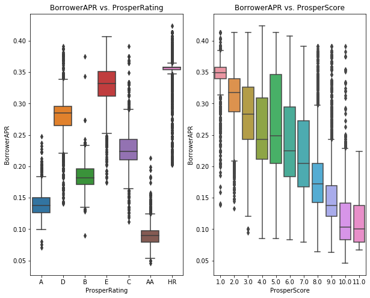

```python
# Violin plot for BorrowerAPR vs. ProsperRating & ProsperScore. Shows higher rating has lower BorrowerAPR
plt.figure(figsize = [15, 5])

plt.subplot(1, 2, 1)
sb.boxplot(data = df, x = 'ProsperRating (Alpha)', y = 'BorrowerAPR')
plt.gcf().set_size_inches(10, 8)
plt.title('BorrowerAPR vs. ProsperRating')
plt.xlabel('ProsperRating')
plt.ylabel('BorrowerAPR')

plt.subplot(1, 2, 2)
sb.boxplot(data = df, x = 'ProsperScore', y = 'BorrowerAPR')
plt.gcf().set_size_inches(10, 8)
plt.title('BorrowerAPR vs. ProsperScore')
plt.xlabel('ProsperScore')
plt.ylabel('BorrowerAPR');
```

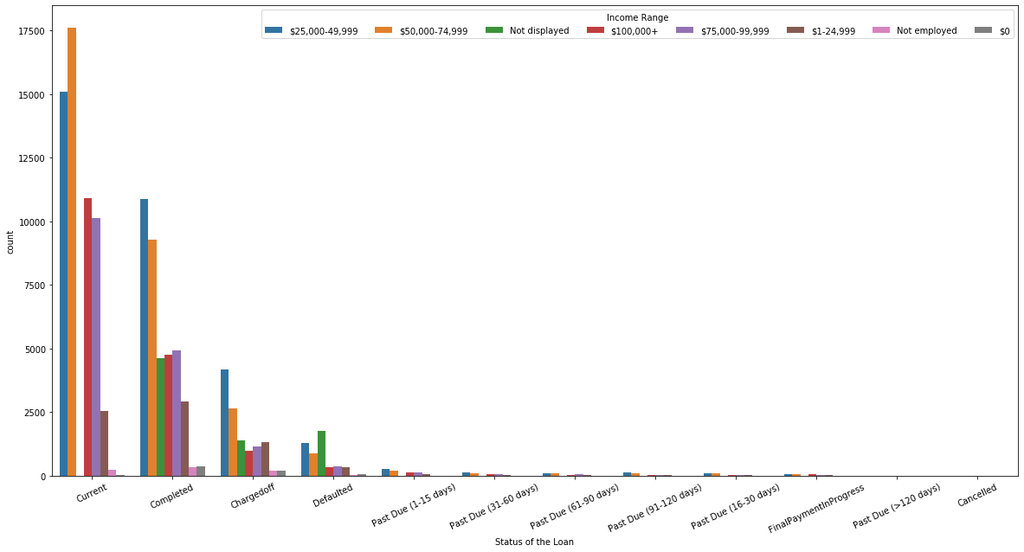

```python
#plotting Income Range against LoanStatus with help of a heat map

plt.figure(figsize = [20,10])
sb.countplot(data = df, x = 'LoanStatus', hue = 'IncomeRange', order = df['LoanStatus'].value_counts().index)
plt.legend(loc = 1, ncol = 8, title = 'Income Range')
plt.xticks(rotation = 25)
plt.xlabel('Status of the Loan');
```

> The Income Range of the borrower does not impact for the loan.

## Multivariate Exploration

> Create plots of three or more variables to investigate your data even further. Make sure that your investigations are justified, and follow from your work in the previous sections.

> let's find the relationship between the status/outcome of a loan and the Prosper Score in relation to the interest rate, On time Payments.

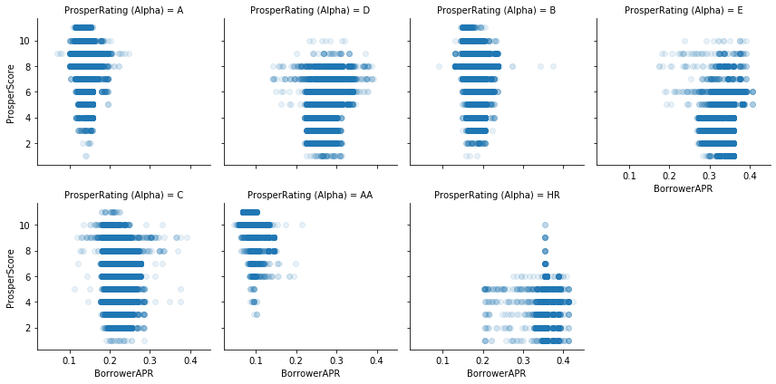

```python
g = sb.FacetGrid(data = df, col = 'ProsperRating (Alpha)', col_wrap = 4, size = 3)
g.map(plt.scatter, 'BorrowerAPR', 'ProsperScore', alpha = 0.1)
g.set_xlabels('BorrowerAPR')
g.set_ylabels('ProsperScore')

plt.show()
```

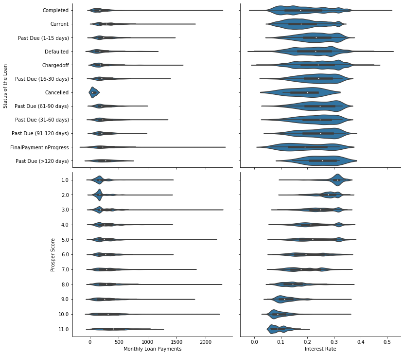

```python
g = sb.PairGrid(data = df, x_vars = ['MonthlyLoanPayment', 'BorrowerRate'],
                y_vars = ['LoanStatus','ProsperScore'], height = 5, aspect = 1)
g.map(sb.violinplot)
g.axes[1,0].set_xlabel('Monthly Loan Payments')
g.axes[1,1].set_xlabel('Interest Rate')
g.axes[0,0].set_ylabel('Status of the Loan')
g.axes[1,0].set_ylabel('Prosper Score')
```

### Talk about some of the relationships you observed in this part of the investigation. Were there features that strengthened each other in terms of looking at your feature(s) of interest?

> From the plot we can see that interest rate and prosper rate correlation with prosper score and loan status.

> At the end of your report, make sure that you export the notebook as an html file from the `File > Download as... > HTML` menu. Make sure you keep track of where the exported file goes, so you can put it in the same folder as this notebook for project submission. Also, make sure you remove all of the quote-formatted guide notes like this one before you finish your report!